# Agency Reports

Office of Marketing and Brand Management

2/20/2020

# Undergraduate Program

# FB_DISP_UG

Run Time: August 15 - June 30

### Seven Day

Seven day report completed on 2019-09-04

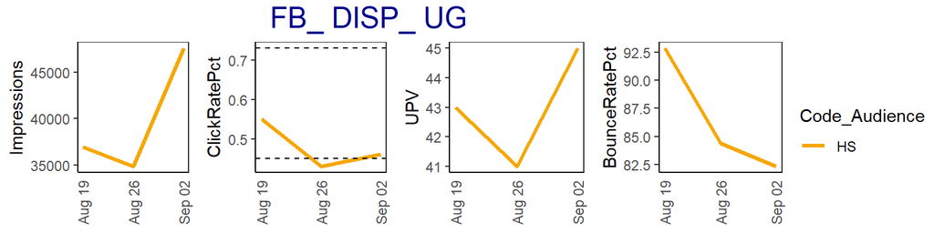

| Code_Audience | YTD_Impressions | Avg_CTR | YTD_UPV | Avg_BR |
| --- | --- | --- | --- | --- |
| HS | 119,446 | 0.48% | 129 | 87.04% |

### Sixty Day

Midterm report completed on 2019-10-14

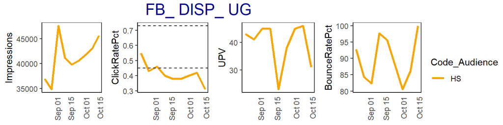

| Code_Audience | YTD_Impressions | Avg_CTR | YTD_UPV | Avg_BR |
| --- | --- | --- | --- | --- |
| HS | 371,468 | 0.41% | 357 | 89.71% |

### Year to Date

Final/Fiscal YTD report summarizes performance through 2020-03-02

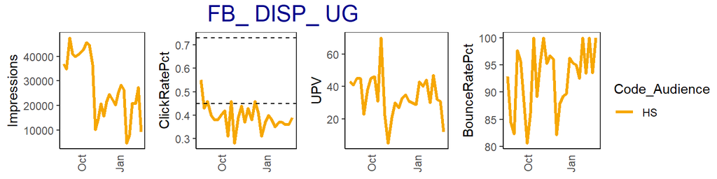

| Code_Audience | YTD_Impressions | Avg_CTR | YTD_UPV | Avg_BR |
| --- | --- | --- | --- | --- |
| HS | 772,476 | 0.4% | 969 | 92.16% |

# IG_DISP_UG

Run Time: August 15 - June 30

### Seven Day

Seven day report completed on 2019-09-04

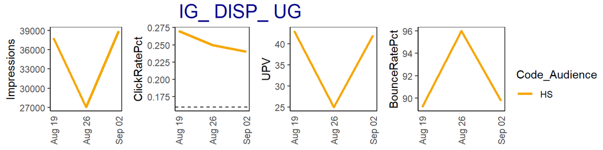

| Code_Audience | YTD_Impressions | Avg_CTR | YTD_UPV | Avg_BR |
| --- | --- | --- | --- | --- |
| HS | 103,804 | 0.25% | 110 | 91.09% |

### Sixty Day:

Midterm report completed on 2019-10-14

[figure not shown]

[output not shown]

### Year to Date

Final/Fiscal YTD report summarizes performance through 2020-03-02

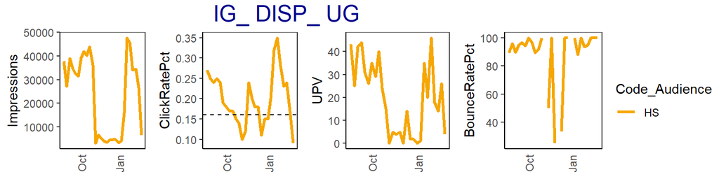

| Code_Audience | YTD_Impressions | Avg_CTR | YTD_UPV | Avg_BR |
| --- | --- | --- | --- | --- |
| HS | 657,804 | 0.22% | 550 | 93.35% |

# TW_DISP_UG

Run Time: September 1 - November 30

### Seven Day

Seven day report completed on 2019-09-18

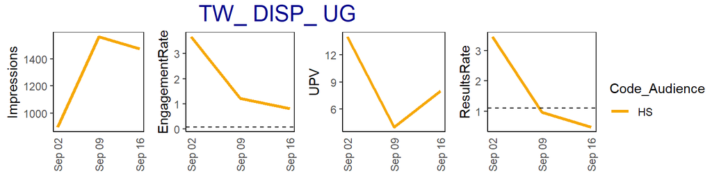

| Code_Audience | YTD_Impressions | Avg_ER | YTD_UPV | Avg_RR |
| --- | --- | --- | --- | --- |
| HS | 3,934 | 1.63% | 26 | 1.35% |

### Sixty Day Report

Midterm report completed on 2019-10-28

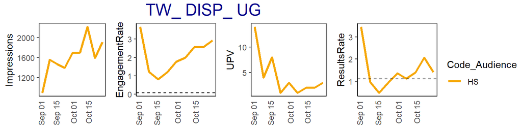

| Code_Audience | YTD_Impressions | Avg_ER | YTD_UPV | Avg_RR |
| --- | --- | --- | --- | --- |
| HS | 14,454 | 2.07% | 38 | 1.38% |

### Year to Date

Final/Fiscal YTD report summarizes performance through 2020-01-13

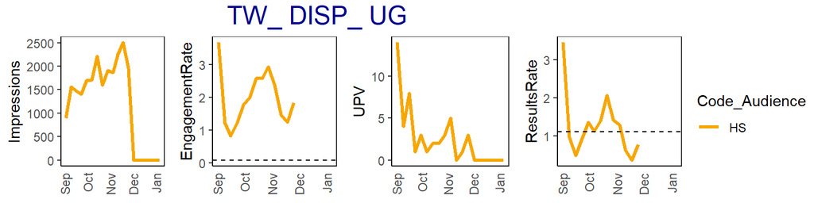

| Code_Audience | YTD_Impressions | Avg_ER | YTD_UPV | Avg_RR |
| --- | --- | --- | --- | --- |
| HS | 23,031 | 1.92% | 47 | 1.13% |

# DBM_DISP_UG

Run Time: August 15 - April 30

### Seven Day

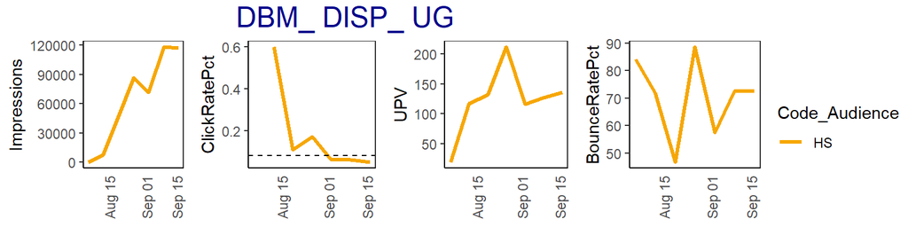

| Code_Audience | YTD_Impressions | Avg_CTR | YTD_UPV | Avg_BR |
| --- | --- | --- | --- | --- |
| HS | 448,105 | 0.09% | 859 | 70.98% |

### Sixty Day

Midterm report completed on 2019-09-30

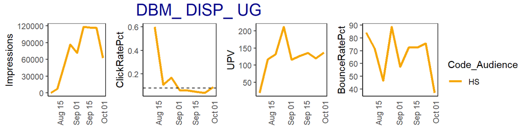

| Code_Audience | YTD_Impressions | Avg_CTR | YTD_UPV | Avg_BR |
| --- | --- | --- | --- | --- |
| HS | 627,008 | 0.08% | 1,116 | 67.26% |

### Year to Date

Final/Fiscal YTD report summarizes performance through 2020-03-02

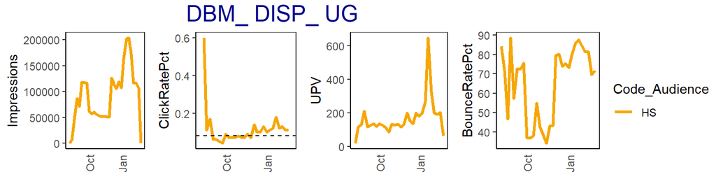

| Code_Audience | YTD_Impressions | Avg_CTR | YTD_UPV | Avg_BR |
| --- | --- | --- | --- | --- |
| HS | 2,713,508 | 0.11% | 5,058 | 70.39% |

# PIN_DISP_UG

Run Time: September 1 - November 30

### Seven Day

Seven day report completed on 2019-09-21

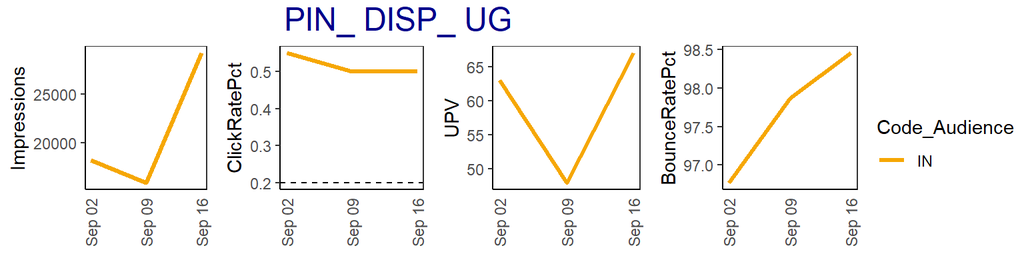

| Code_Audience | YTD_Impressions | Avg_CTR | YTD_UPV | Avg_BR |
| --- | --- | --- | --- | --- |
| IN | 63,295 | 0.51% | 178 | 97.7% |

### Sixty Day Report

Midterm report completed on 2019-10-31

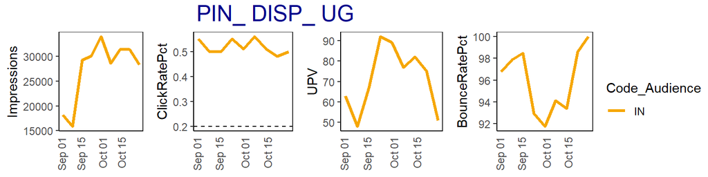

| Code_Audience | YTD_Impressions | Avg_CTR | YTD_UPV | Avg_BR |
| --- | --- | --- | --- | --- |
| IN | 247,296 | 0.52% | 644 | 95.57% |

### Year to Date

Final/Fiscal YTD report summarizes performance through 2019-11-18

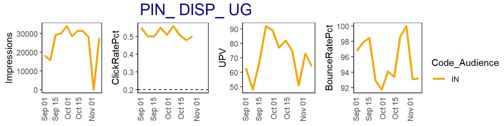

| Code_Audience | YTD_Impressions | Avg_CTR | YTD_UPV | Avg_BR |
| --- | --- | --- | --- | --- |
| IN | 274,819 | 0.51% | 781 | 95.19% |

# SC_VID Phase 1 Run Time: October 29 - November 30

**Note:** Looks like this campaign ran through mid-February.

### Seven Day

Seven day report completed on 2019-11-18

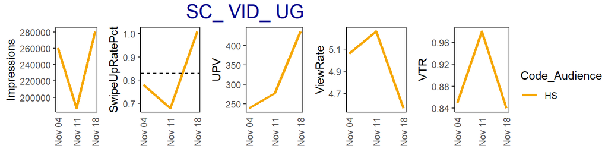

| Code_Audience | YTD_Impressions | Avg_Swipe_Rate | YTD_UPV | Avg_BR | Avg_View_Rate | Avg_VTR |
| --- | --- | --- | --- | --- | --- | --- |
| HS | 728,222 | 0.84% | 954 | 94.92% | 4.92% | 17.9% |

### Sixty Day Report

Midterm report completed on 2019-12-28

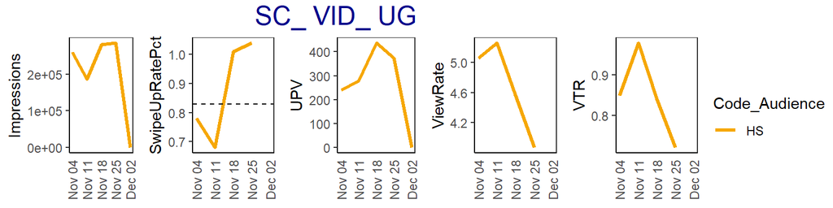

| Code_Audience | YTD_Impressions | Avg_Swipe_Rate | YTD_UPV | Avg_BR | Avg_View_Rate | Avg_VTR |
| --- | --- | --- | --- | --- | --- | --- |
| HS | 1,013,308 | 0.9% | 1,328 | 95.75% | 4.63% | 18.07% |

### Year to Date

Final/Fiscal YTD report summarizes performance through 2020-03-02

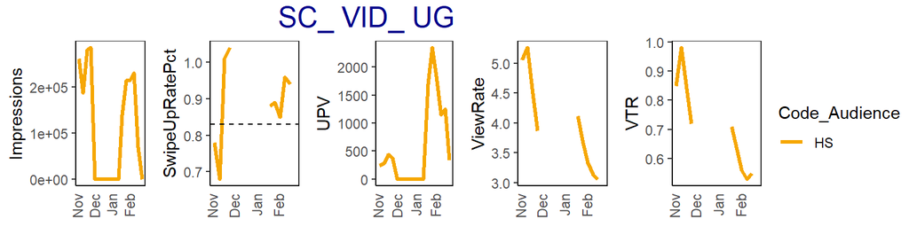

| Code_Audience | YTD_Impressions | Avg_Swipe_Rate | YTD_UPV | Avg_BR | Avg_View_Rate | Avg_VTR |
| --- | --- | --- | --- | --- | --- | --- |
| HS | 1,881,168 | 0.9% | 9,942 | 97.76% | 4.09% | 17.69% |

# SC_VID Phase 2 Run Time: March 1 - May 31

### Seven Day

Seven day report completed on 2020-03-21

| Code_Audience | YTD_Impressions | Avg_Swipe_Rate | YTD_UPV | Avg_BR | Avg_View_Rate | Avg_VTR |
| --- | --- | --- | --- | --- | --- | --- |

### Sixty Day Report

Midterm report completed on 2020-04-30

| Code_Audience | YTD_Impressions | Avg_Swipe_Rate | YTD_UPV | Avg_BR | Avg_View_Rate | Avg_VTR |
| --- | --- | --- | --- | --- | --- | --- |

### Year to Date

| Code_Audience | YTD_Impressions | Avg_Swipe_Rate | YTD_UPV | Avg_BR | Avg_View_Rate | Avg_VTR |
| --- | --- | --- | --- | --- | --- | --- |

# YouTube

Phase 1 Run Time: October 29 - November 30

### Seven Day

Seven day report completed on 2019-11-18

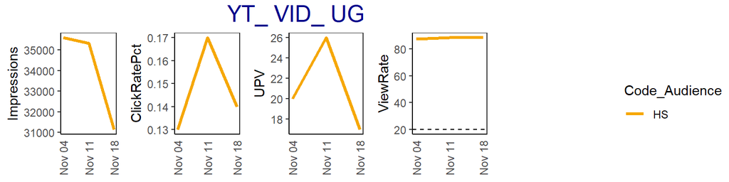

| Code_Audience | YTD_Impressions | ClickRatePct | YTD_UPV | Avg_BR | Avg_View_Rate | Avg_VTR |
| --- | --- | --- | --- | --- | --- | --- |
| HS | 102,080 | 0.15% | 63 | 87.3% | 88.08% | 91.33% |

### Sixty Day Report

Midterm report completed on 2019-12-28

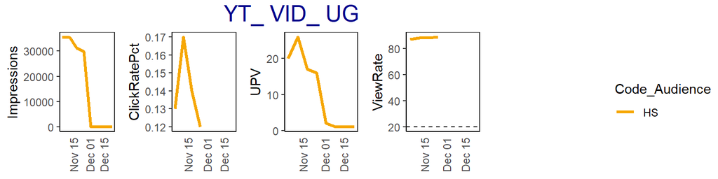

| Code_Audience | YTD_Impressions | ClickRatePct | YTD_UPV | Avg_BR | Avg_View_Rate | Avg_VTR |
| --- | --- | --- | --- | --- | --- | --- |
| HS | 131,982 | 0.14% | 83 | 86.59% | 88.32% | 91.46% |

### Year to Date

Final/Fiscal YTD report summarizes performance through 2020-02-03

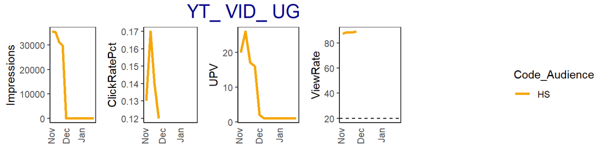

| Code_Audience | YTD_Impressions | ClickRatePct | YTD_UPV | Avg_BR | Avg_View_Rate | Avg_VTR |
| --- | --- | --- | --- | --- | --- | --- |
| HS | 131,982 | 0.14% | 84 | 86.75% | 88.32% | 91.46% |